# Risk Factor Analysis

## Outcome Variable

**Outcome Variable:** stunted

## Predictor Variables

**Intervention Variable:** vagbrth

**Adjustment Set:**

unadjusted

## Stratifying Variables

The analysis was stratified on these variable(s):

- agecat
- studyid
- country

## Data Summary

| agecat | studyid | country | A | n | nA | nAY0 | nAY1 |
| --- | --- | --- | --- | --- | --- | --- | --- |
| Birth | ki1000108-CMC-V-BCS-2002 | INDIA | 0 | 90 | 11 | 9 | 2 |
| Birth | ki1000108-CMC-V-BCS-2002 | INDIA | 1 | 90 | 79 | 65 | 14 |
| Birth | ki1000108-IRC | INDIA | 0 | 388 | 68 | 58 | 10 |
| Birth | ki1000108-IRC | INDIA | 1 | 388 | 320 | 285 | 35 |
| Birth | ki1017093c-NIH-Crypto | BANGLADESH | 0 | 19 | 1 | 1 | 0 |
| Birth | ki1017093c-NIH-Crypto | BANGLADESH | 1 | 19 | 18 | 15 | 3 |
| Birth | ki1119695-PROBIT | BELARUS | 0 | 6779 | 716 | 713 | 3 |
| Birth | ki1119695-PROBIT | BELARUS | 1 | 6779 | 6063 | 6045 | 18 |
| Birth | ki1126311-ZVITAMBO | ZIMBABWE | 0 | 13716 | 1162 | 1073 | 89 |
| Birth | ki1126311-ZVITAMBO | ZIMBABWE | 1 | 13716 | 12554 | 11233 | 1321 |
| Birth | kiGH5241-JiVitA-3 | BANGLADESH | 0 | 9731 | 1 | 0 | 1 |
| Birth | kiGH5241-JiVitA-3 | BANGLADESH | 1 | 9731 | 9730 | 6411 | 3319 |
| Birth | kiGH5241-JiVitA-4 | BANGLADESH | 0 | 224 | 0 | 0 | 0 |
| Birth | kiGH5241-JiVitA-4 | BANGLADESH | 1 | 224 | 224 | 155 | 69 |
| 3 months | ki1000108-CMC-V-BCS-2002 | INDIA | 0 | 362 | 25 | 20 | 5 |
| 3 months | ki1000108-CMC-V-BCS-2002 | INDIA | 1 | 362 | 337 | 252 | 85 |
| 3 months | ki1000108-IRC | INDIA | 0 | 407 | 69 | 51 | 18 |
| 3 months | ki1000108-IRC | INDIA | 1 | 407 | 338 | 265 | 73 |
| 3 months | ki1017093b-PROVIDE | BANGLADESH | 0 | 645 | 150 | 136 | 14 |
| 3 months | ki1017093b-PROVIDE | BANGLADESH | 1 | 645 | 495 | 431 | 64 |
| 3 months | ki1017093c-NIH-Crypto | BANGLADESH | 0 | 471 | 193 | 159 | 34 |
| 3 months | ki1017093c-NIH-Crypto | BANGLADESH | 1 | 471 | 278 | 215 | 63 |
| 3 months | ki1066203-TanzaniaChild2 | TANZANIA, UNITED REPUBLIC OF | 0 | 2265 | 201 | 188 | 13 |
| 3 months | ki1066203-TanzaniaChild2 | TANZANIA, UNITED REPUBLIC OF | 1 | 2265 | 2064 | 1940 | 124 |
| 3 months | ki1119695-PROBIT | BELARUS | 0 | 8057 | 845 | 775 | 70 |
| 3 months | ki1119695-PROBIT | BELARUS | 1 | 8057 | 7212 | 6776 | 436 |
| 3 months | ki1126311-ZVITAMBO | ZIMBABWE | 0 | 9123 | 797 | 663 | 134 |
| 3 months | ki1126311-ZVITAMBO | ZIMBABWE | 1 | 9123 | 8326 | 6834 | 1492 |
| 3 months | kiGH5241-JiVitA-3 | BANGLADESH | 0 | 12270 | 700 | 579 | 121 |
| 3 months | kiGH5241-JiVitA-3 | BANGLADESH | 1 | 12270 | 11570 | 8303 | 3267 |

[output cut: 88 more lines]

The following strata were considered:

- agecat: 12 months, studyid: ki1000108-CMC-V-BCS-2002, country: INDIA
- agecat: 12 months, studyid: ki1000108-IRC, country: INDIA
- agecat: 12 months, studyid: ki1017093b-PROVIDE, country: BANGLADESH
- agecat: 12 months, studyid: ki1017093c-NIH-Crypto, country: BANGLADESH
- agecat: 12 months, studyid: ki1066203-TanzaniaChild2, country: TANZANIA, UNITED REPUBLIC OF
- agecat: 12 months, studyid: ki1119695-PROBIT, country: BELARUS
- agecat: 12 months, studyid: ki1126311-ZVITAMBO, country: ZIMBABWE
- agecat: 12 months, studyid: kiGH5241-JiVitA-3, country: BANGLADESH
- agecat: 12 months, studyid: kiGH5241-JiVitA-4, country: BANGLADESH
- agecat: 18 months, studyid: ki1000108-CMC-V-BCS-2002, country: INDIA
- agecat: 18 months, studyid: ki1000108-IRC, country: INDIA
- agecat: 18 months, studyid: ki1017093b-PROVIDE, country: BANGLADESH
- agecat: 18 months, studyid: ki1017093c-NIH-Crypto, country: BANGLADESH
- agecat: 18 months, studyid: ki1066203-TanzaniaChild2, country: TANZANIA, UNITED REPUBLIC OF
- agecat: 18 months, studyid: ki1119695-PROBIT, country: BELARUS
- agecat: 18 months, studyid: ki1126311-ZVITAMBO, country: ZIMBABWE
- agecat: 18 months, studyid: kiGH5241-JiVitA-4, country: BANGLADESH
- agecat: 24 months, studyid: ki1000108-CMC-V-BCS-2002, country: INDIA
- agecat: 24 months, studyid: ki1000108-IRC, country: INDIA
- agecat: 24 months, studyid: ki1017093b-PROVIDE, country: BANGLADESH
- agecat: 24 months, studyid: ki1017093c-NIH-Crypto, country: BANGLADESH
- agecat: 24 months, studyid: ki1066203-TanzaniaChild2, country: TANZANIA, UNITED REPUBLIC OF
- agecat: 24 months, studyid: ki1119695-PROBIT, country: BELARUS
- agecat: 24 months, studyid: ki1126311-ZVITAMBO, country: ZIMBABWE
- agecat: 24 months, studyid: kiGH5241-JiVitA-3, country: BANGLADESH
- agecat: 24 months, studyid: kiGH5241-JiVitA-4, country: BANGLADESH
- agecat: 3 months, studyid: ki1000108-CMC-V-BCS-2002, country: INDIA
- agecat: 3 months, studyid: ki1000108-IRC, country: INDIA
- agecat: 3 months, studyid: ki1017093b-PROVIDE, country: BANGLADESH
- agecat: 3 months, studyid: ki1017093c-NIH-Crypto, country: BANGLADESH
- agecat: 3 months, studyid: ki1066203-TanzaniaChild2, country: TANZANIA, UNITED REPUBLIC OF
- agecat: 3 months, studyid: ki1119695-PROBIT, country: BELARUS
- agecat: 3 months, studyid: ki1126311-ZVITAMBO, country: ZIMBABWE
- agecat: 3 months, studyid: kiGH5241-JiVitA-3, country: BANGLADESH
- agecat: 3 months, studyid: kiGH5241-JiVitA-4, country: BANGLADESH
- agecat: 6 months, studyid: ki1000108-CMC-V-BCS-2002, country: INDIA
- agecat: 6 months, studyid: ki1000108-IRC, country: INDIA
- agecat: 6 months, studyid: ki1017093b-PROVIDE, country: BANGLADESH
- agecat: 6 months, studyid: ki1017093c-NIH-Crypto, country: BANGLADESH
- agecat: 6 months, studyid: ki1066203-TanzaniaChild2, country: TANZANIA, UNITED REPUBLIC OF
- agecat: 6 months, studyid: ki1119695-PROBIT, country: BELARUS
- agecat: 6 months, studyid: ki1126311-ZVITAMBO, country: ZIMBABWE
- agecat: 6 months, studyid: kiGH5241-JiVitA-3, country: BANGLADESH
- agecat: 6 months, studyid: kiGH5241-JiVitA-4, country: BANGLADESH
- agecat: 9 months, studyid: ki1000108-CMC-V-BCS-2002, country: INDIA
- agecat: 9 months, studyid: ki1000108-IRC, country: INDIA
- agecat: 9 months, studyid: ki1017093b-PROVIDE, country: BANGLADESH
- agecat: 9 months, studyid: ki1017093c-NIH-Crypto, country: BANGLADESH
- agecat: 9 months, studyid: ki1066203-TanzaniaChild2, country: TANZANIA, UNITED REPUBLIC OF
- agecat: 9 months, studyid: ki1119695-PROBIT, country: BELARUS
- agecat: 9 months, studyid: ki1126311-ZVITAMBO, country: ZIMBABWE
- agecat: 9 months, studyid: kiGH5241-JiVitA-4, country: BANGLADESH
- agecat: Birth, studyid: ki1000108-CMC-V-BCS-2002, country: INDIA
- agecat: Birth, studyid: ki1000108-IRC, country: INDIA
- agecat: Birth, studyid: ki1017093c-NIH-Crypto, country: BANGLADESH
- agecat: Birth, studyid: ki1119695-PROBIT, country: BELARUS
- agecat: Birth, studyid: ki1126311-ZVITAMBO, country: ZIMBABWE
- agecat: Birth, studyid: kiGH5241-JiVitA-3, country: BANGLADESH
- agecat: Birth, studyid: kiGH5241-JiVitA-4, country: BANGLADESH

### Dropped Strata

Some strata were dropped due to rare outcomes:

- agecat: Birth, studyid: ki1000108-CMC-V-BCS-2002, country: INDIA
- agecat: Birth, studyid: ki1017093c-NIH-Crypto, country: BANGLADESH
- agecat: Birth, studyid: ki1119695-PROBIT, country: BELARUS
- agecat: Birth, studyid: kiGH5241-JiVitA-3, country: BANGLADESH
- agecat: Birth, studyid: kiGH5241-JiVitA-4, country: BANGLADESH
- agecat: 24 months, studyid: ki1066203-TanzaniaChild2, country: TANZANIA, UNITED REPUBLIC OF

## Methods Detail

We’re interested in the causal parameters $E[Y_a]$ for all values of $a \in \mathcal{A}$. These parameters represent the mean outcome if, possibly contrary to fact, we intervened to set all units to have $A=a$. Under the randomization and positivity assumptions, these are identified by the statistical parameters $\psi_a=E_W[E_{Y|A,W}(Y|A=a,W)]$. In addition, we’re interested in the mean of $Y$, $E[Y]$ under no intervention (the observed mean). We will estimate these parameters by using SuperLearner to fit the relevant likelihood factors – $E_{Y|A,W}(Y|A=a,W)$ and $p(A=a|W)$, and then updating our likelihood fit using a joint TMLE.

For unadjusted analyses ($W=\{\}$), initial likelihoods were estimated using Lrnr_glm to estimate the simple $E(Y|A)$ and Lrnr_mean to estimate $p(A)$. For adjusted analyses, a small library containing Lrnr_glmnet, Lrnr_xgboost, and Lrnr_mean was used.

Having estimated these parameters, we will then use the delta method to estimate relative risks and attributable risks relative to a prespecified baseline level of $A$.

# Results Detail

## Results Plots

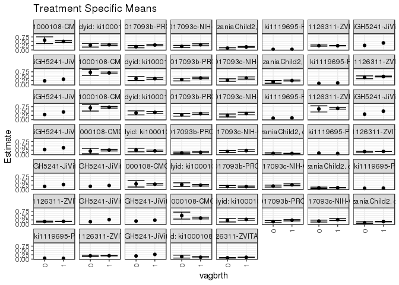

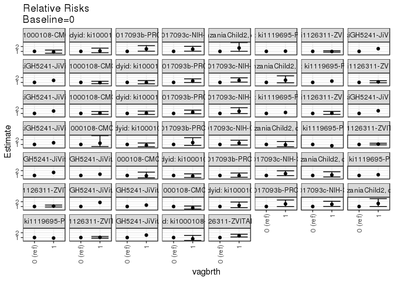

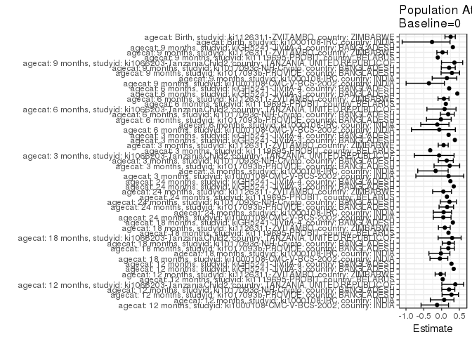

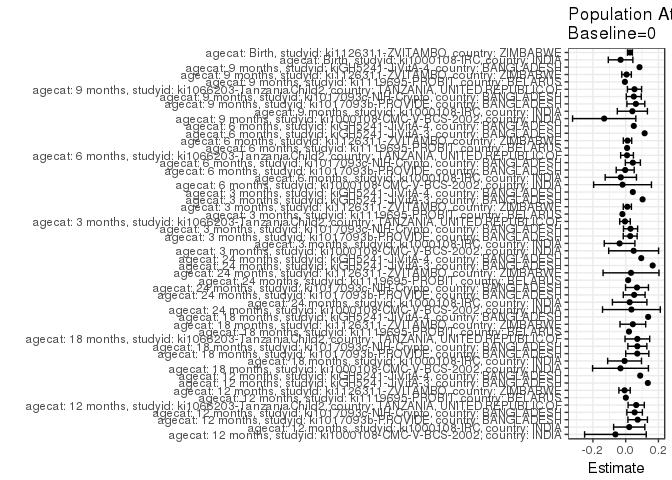

## Results Table

### Parameter: TSM

| agecat | studyid | country | intervention_level | baseline_level | estimate | ci_lower | ci_upper |
| --- | --- | --- | --- | --- | --- | --- | --- |
| Birth | ki1000108-IRC | INDIA | 0 | NA | 0.1470588 | 0.0627721 | 0.2313455 |
| Birth | ki1000108-IRC | INDIA | 1 | NA | 0.1093750 | 0.0751345 | 0.1436155 |
| Birth | ki1126311-ZVITAMBO | ZIMBABWE | 0 | NA | 0.0765921 | 0.0613006 | 0.0918836 |
| Birth | ki1126311-ZVITAMBO | ZIMBABWE | 1 | NA | 0.1052254 | 0.0998577 | 0.1105931 |
| 3 months | ki1000108-CMC-V-BCS-2002 | INDIA | 0 | NA | 0.2000000 | 0.0429859 | 0.3570141 |
| 3 months | ki1000108-CMC-V-BCS-2002 | INDIA | 1 | NA | 0.2522255 | 0.2057939 | 0.2986571 |
| 3 months | ki1000108-IRC | INDIA | 0 | NA | 0.2608696 | 0.1571334 | 0.3646057 |
| 3 months | ki1000108-IRC | INDIA | 1 | NA | 0.2159763 | 0.1720534 | 0.2598993 |
| 3 months | ki1017093b-PROVIDE | BANGLADESH | 0 | NA | 0.0933333 | 0.0467445 | 0.1399221 |
| 3 months | ki1017093b-PROVIDE | BANGLADESH | 1 | NA | 0.1292929 | 0.0997124 | 0.1588735 |
| 3 months | ki1017093c-NIH-Crypto | BANGLADESH | 0 | NA | 0.1761658 | 0.1223622 | 0.2299694 |
| 3 months | ki1017093c-NIH-Crypto | BANGLADESH | 1 | NA | 0.2266187 | 0.1773544 | 0.2758830 |
| 3 months | ki1066203-TanzaniaChild2 | TANZANIA, UNITED REPUBLIC OF | 0 | NA | 0.0646766 | 0.0306671 | 0.0986861 |
| 3 months | ki1066203-TanzaniaChild2 | TANZANIA, UNITED REPUBLIC OF | 1 | NA | 0.0600775 | 0.0498236 | 0.0703315 |
| 3 months | ki1119695-PROBIT | BELARUS | 0 | NA | 0.0828402 | NA | NA |
| 3 months | ki1119695-PROBIT | BELARUS | 1 | NA | 0.0604548 | NA | NA |
| 3 months | ki1126311-ZVITAMBO | ZIMBABWE | 0 | NA | 0.1681305 | 0.1421652 | 0.1940958 |
| 3 months | ki1126311-ZVITAMBO | ZIMBABWE | 1 | NA | 0.1791977 | 0.1709594 | 0.1874360 |
| 3 months | kiGH5241-JiVitA-3 | BANGLADESH | 0 | NA | 0.1728571 | NA | NA |
| 3 months | kiGH5241-JiVitA-3 | BANGLADESH | 1 | NA | 0.2823682 | NA | NA |
| 3 months | kiGH5241-JiVitA-4 | BANGLADESH | 0 | NA | 0.1774194 | NA | NA |
| 3 months | kiGH5241-JiVitA-4 | BANGLADESH | 1 | NA | 0.2244641 | NA | NA |
| 6 months | ki1000108-CMC-V-BCS-2002 | INDIA | 0 | NA | 0.3200000 | 0.1368964 | 0.5031036 |
| 6 months | ki1000108-CMC-V-BCS-2002 | INDIA | 1 | NA | 0.2994186 | 0.2509538 | 0.3478835 |
| 6 months | ki1000108-IRC | INDIA | 0 | NA | 0.2753623 | 0.1698337 | 0.3808910 |
| 6 months | ki1000108-IRC | INDIA | 1 | NA | 0.2396450 | 0.1940816 | 0.2852084 |
| 6 months | ki1017093b-PROVIDE | BANGLADESH | 0 | NA | 0.1641791 | 0.1014045 | 0.2269537 |
| 6 months | ki1017093b-PROVIDE | BANGLADESH | 1 | NA | 0.1603563 | 0.1263869 | 0.1943258 |
| 6 months | ki1017093c-NIH-Crypto | BANGLADESH | 0 | NA | 0.1925134 | 0.1359414 | 0.2490853 |
| 6 months | ki1017093c-NIH-Crypto | BANGLADESH | 1 | NA | 0.2666667 | 0.2138614 | 0.3194719 |

[output cut: 76 more lines]

### Parameter: E(Y)

| agecat | studyid | country | intervention_level | baseline_level | estimate | ci_lower | ci_upper |
| --- | --- | --- | --- | --- | --- | --- | --- |
| Birth | ki1000108-IRC | INDIA | NA | NA | 0.1159794 | 0.0840777 | 0.1478811 |
| Birth | ki1126311-ZVITAMBO | ZIMBABWE | NA | NA | 0.1027997 | 0.0977170 | 0.1078823 |
| 3 months | ki1000108-CMC-V-BCS-2002 | INDIA | NA | NA | 0.2486188 | 0.2040335 | 0.2932041 |
| 3 months | ki1000108-IRC | INDIA | NA | NA | 0.2235872 | 0.1830592 | 0.2641152 |
| 3 months | ki1017093b-PROVIDE | BANGLADESH | NA | NA | 0.1209302 | 0.0957486 | 0.1461119 |
| 3 months | ki1017093c-NIH-Crypto | BANGLADESH | NA | NA | 0.2059448 | 0.1693853 | 0.2425043 |
| 3 months | ki1066203-TanzaniaChild2 | TANZANIA, UNITED REPUBLIC OF | NA | NA | 0.0604857 | 0.0506662 | 0.0703051 |
| 3 months | ki1119695-PROBIT | BELARUS | NA | NA | 0.0628025 | NA | NA |
| 3 months | ki1126311-ZVITAMBO | ZIMBABWE | NA | NA | 0.1782308 | 0.1703772 | 0.1860845 |
| 3 months | kiGH5241-JiVitA-3 | BANGLADESH | NA | NA | 0.2761206 | NA | NA |
| 3 months | kiGH5241-JiVitA-4 | BANGLADESH | NA | NA | 0.2210526 | NA | NA |
| 6 months | ki1000108-CMC-V-BCS-2002 | INDIA | NA | NA | 0.3008130 | 0.2539566 | 0.3476694 |
| 6 months | ki1000108-IRC | INDIA | NA | NA | 0.2457002 | 0.2038248 | 0.2875757 |
| 6 months | ki1017093b-PROVIDE | BANGLADESH | NA | NA | 0.1612350 | 0.1313580 | 0.1911120 |
| 6 months | ki1017093c-NIH-Crypto | BANGLADESH | NA | NA | 0.2363239 | 0.1973320 | 0.2753157 |
| 6 months | ki1066203-TanzaniaChild2 | TANZANIA, UNITED REPUBLIC OF | NA | NA | 0.0982544 | 0.0852222 | 0.1112866 |
| 6 months | ki1119695-PROBIT | BELARUS | NA | NA | 0.0713633 | NA | NA |
| 6 months | ki1126311-ZVITAMBO | ZIMBABWE | NA | NA | 0.1667477 | 0.1586931 | 0.1748023 |
| 6 months | kiGH5241-JiVitA-3 | BANGLADESH | NA | NA | 0.2619507 | NA | NA |
| 6 months | kiGH5241-JiVitA-4 | BANGLADESH | NA | NA | 0.2326686 | NA | NA |
| 9 months | ki1000108-CMC-V-BCS-2002 | INDIA | NA | NA | 0.3688525 | 0.3193538 | 0.4183511 |
| 9 months | ki1000108-IRC | INDIA | NA | NA | 0.2727273 | 0.2294063 | 0.3160482 |
| 9 months | ki1017093b-PROVIDE | BANGLADESH | NA | NA | 0.2132231 | 0.1805589 | 0.2458874 |
| 9 months | ki1017093c-NIH-Crypto | BANGLADESH | NA | NA | 0.2333333 | 0.1942117 | 0.2724549 |
| 9 months | ki1066203-TanzaniaChild2 | TANZANIA, UNITED REPUBLIC OF | NA | NA | 0.1491525 | 0.1325519 | 0.1657532 |
| 9 months | ki1119695-PROBIT | BELARUS | NA | NA | 0.0449018 | NA | NA |
| 9 months | ki1126311-ZVITAMBO | ZIMBABWE | NA | NA | 0.1975292 | 0.1885829 | 0.2064755 |
| 9 months | kiGH5241-JiVitA-4 | BANGLADESH | NA | NA | 0.2663551 | NA | NA |
| 12 months | ki1000108-CMC-V-BCS-2002 | INDIA | NA | NA | 0.4972826 | 0.4461287 | 0.5484365 |
| 12 months | ki1000108-IRC | INDIA | NA | NA | 0.2931034 | 0.2487723 | 0.3374346 |
| 12 months | ki1017093b-PROVIDE | BANGLADESH | NA | NA | 0.2616667 | 0.2264673 | 0.2968661 |
| 12 months | ki1017093c-NIH-Crypto | BANGLADESH | NA | NA | 0.2600000 | 0.2194279 | 0.3005721 |
| 12 months | ki1066203-TanzaniaChild2 | TANZANIA, UNITED REPUBLIC OF | NA | NA | 0.1664326 | 0.1470802 | 0.1857850 |
| 12 months | ki1119695-PROBIT | BELARUS | NA | NA | 0.0341262 | NA | NA |
| 12 months | ki1126311-ZVITAMBO | ZIMBABWE | NA | NA | 0.2440592 | 0.2337666 | 0.2543518 |
| 12 months | kiGH5241-JiVitA-3 | BANGLADESH | NA | NA | 0.3965998 | NA | NA |
| 12 months | kiGH5241-JiVitA-4 | BANGLADESH | NA | NA | 0.3183940 | NA | NA |
| 18 months | ki1000108-CMC-V-BCS-2002 | INDIA | NA | NA | 0.6883469 | 0.6410248 | 0.7356689 |
| 18 months | ki1000108-IRC | INDIA | NA | NA | 0.3555556 | 0.3088785 | 0.4022327 |
| 18 months | ki1017093b-PROVIDE | BANGLADESH | NA | NA | 0.3731884 | 0.3328048 | 0.4135720 |
| 18 months | ki1017093c-NIH-Crypto | BANGLADESH | NA | NA | 0.3447368 | 0.2968870 | 0.3925867 |
| 18 months | ki1066203-TanzaniaChild2 | TANZANIA, UNITED REPUBLIC OF | NA | NA | 0.2399173 | 0.2129882 | 0.2668463 |
| 18 months | ki1119695-PROBIT | BELARUS | NA | NA | 0.1034031 | NA | NA |
| 18 months | ki1126311-ZVITAMBO | ZIMBABWE | NA | NA | 0.4763593 | 0.4525548 | 0.5001639 |
| 18 months | kiGH5241-JiVitA-4 | BANGLADESH | NA | NA | 0.4330784 | NA | NA |
| 24 months | ki1000108-CMC-V-BCS-2002 | INDIA | NA | NA | 0.7150538 | 0.6691221 | 0.7609854 |
| 24 months | ki1000108-IRC | INDIA | NA | NA | 0.4156479 | 0.3678270 | 0.4634689 |
| 24 months | ki1017093b-PROVIDE | BANGLADESH | NA | NA | 0.3292894 | 0.2909105 | 0.3676684 |
| 24 months | ki1017093c-NIH-Crypto | BANGLADESH | NA | NA | 0.3115385 | 0.2551365 | 0.3679404 |
| 24 months | ki1119695-PROBIT | BELARUS | NA | NA | 0.1000618 | NA | NA |
| 24 months | ki1126311-ZVITAMBO | ZIMBABWE | NA | NA | 0.6533333 | 0.6093135 | 0.6973532 |
| 24 months | kiGH5241-JiVitA-3 | BANGLADESH | NA | NA | 0.4819588 | NA | NA |
| 24 months | kiGH5241-JiVitA-4 | BANGLADESH | NA | NA | 0.3851224 | NA | NA |

### Parameter: RR

| agecat | studyid | country | intervention_level | baseline_level | estimate | ci_lower | ci_upper |
| --- | --- | --- | --- | --- | --- | --- | --- |
| Birth | ki1000108-IRC | INDIA | 0 | 0 | 1.0000000 | 1.0000000 | 1.000000 |
| Birth | ki1000108-IRC | INDIA | 1 | 0 | 0.7437500 | 0.3870802 | 1.429068 |
| Birth | ki1126311-ZVITAMBO | ZIMBABWE | 0 | 0 | 1.0000000 | 1.0000000 | 1.000000 |
| Birth | ki1126311-ZVITAMBO | ZIMBABWE | 1 | 0 | 1.3738421 | 1.1180085 | 1.688218 |
| 3 months | ki1000108-CMC-V-BCS-2002 | INDIA | 0 | 0 | 1.0000000 | 1.0000000 | 1.000000 |
| 3 months | ki1000108-CMC-V-BCS-2002 | INDIA | 1 | 0 | 1.2611276 | 0.5630659 | 2.824612 |
| 3 months | ki1000108-IRC | INDIA | 0 | 0 | 1.0000000 | 1.0000000 | 1.000000 |
| 3 months | ki1000108-IRC | INDIA | 1 | 0 | 0.8279093 | 0.5296742 | 1.294067 |
| 3 months | ki1017093b-PROVIDE | BANGLADESH | 0 | 0 | 1.0000000 | 1.0000000 | 1.000000 |
| 3 months | ki1017093b-PROVIDE | BANGLADESH | 1 | 0 | 1.3852813 | 0.7999581 | 2.398881 |
| 3 months | ki1017093c-NIH-Crypto | BANGLADESH | 0 | 0 | 1.0000000 | 1.0000000 | 1.000000 |
| 3 months | ki1017093c-NIH-Crypto | BANGLADESH | 1 | 0 | 1.2863944 | 0.8842302 | 1.871470 |
| 3 months | ki1066203-TanzaniaChild2 | TANZANIA, UNITED REPUBLIC OF | 0 | 0 | 1.0000000 | 1.0000000 | 1.000000 |
| 3 months | ki1066203-TanzaniaChild2 | TANZANIA, UNITED REPUBLIC OF | 1 | 0 | 0.9288909 | 0.5344005 | 1.614591 |
| 3 months | ki1119695-PROBIT | BELARUS | 0 | 0 | 1.0000000 | NA | NA |
| 3 months | ki1119695-PROBIT | BELARUS | 1 | 0 | 0.7297758 | NA | NA |
| 3 months | ki1126311-ZVITAMBO | ZIMBABWE | 0 | 0 | 1.0000000 | 1.0000000 | 1.000000 |
| 3 months | ki1126311-ZVITAMBO | ZIMBABWE | 1 | 0 | 1.0658251 | 0.9072077 | 1.252175 |
| 3 months | kiGH5241-JiVitA-3 | BANGLADESH | 0 | 0 | 1.0000000 | NA | NA |
| 3 months | kiGH5241-JiVitA-3 | BANGLADESH | 1 | 0 | 1.6335350 | NA | NA |
| 3 months | kiGH5241-JiVitA-4 | BANGLADESH | 0 | 0 | 1.0000000 | NA | NA |
| 3 months | kiGH5241-JiVitA-4 | BANGLADESH | 1 | 0 | 1.2651611 | NA | NA |
| 6 months | ki1000108-CMC-V-BCS-2002 | INDIA | 0 | 0 | 1.0000000 | 1.0000000 | 1.000000 |
| 6 months | ki1000108-CMC-V-BCS-2002 | INDIA | 1 | 0 | 0.9356831 | 0.5162674 | 1.695832 |
| 6 months | ki1000108-IRC | INDIA | 0 | 0 | 1.0000000 | 1.0000000 | 1.000000 |
| 6 months | ki1000108-IRC | INDIA | 1 | 0 | 0.8702896 | 0.5673744 | 1.334928 |
| 6 months | ki1017093b-PROVIDE | BANGLADESH | 0 | 0 | 1.0000000 | 1.0000000 | 1.000000 |
| 6 months | ki1017093b-PROVIDE | BANGLADESH | 1 | 0 | 0.9767159 | 0.6308578 | 1.512186 |
| 6 months | ki1017093c-NIH-Crypto | BANGLADESH | 0 | 0 | 1.0000000 | 1.0000000 | 1.000000 |
| 6 months | ki1017093c-NIH-Crypto | BANGLADESH | 1 | 0 | 1.3851852 | 0.9718846 | 1.974245 |

[output cut: 76 more lines]

### Parameter: PAR

| agecat | studyid | country | intervention_level | baseline_level | estimate | ci_lower | ci_upper |
| --- | --- | --- | --- | --- | --- | --- | --- |
| Birth | ki1000108-IRC | INDIA | 0 | NA | -0.0310794 | -0.1061249 | 0.0439660 |
| Birth | ki1126311-ZVITAMBO | ZIMBABWE | 0 | NA | 0.0262076 | 0.0113737 | 0.0410414 |
| 3 months | ki1000108-CMC-V-BCS-2002 | INDIA | 0 | NA | 0.0486188 | -0.1038152 | 0.2010528 |
| 3 months | ki1000108-IRC | INDIA | 0 | NA | -0.0372823 | -0.1308502 | 0.0562855 |
| 3 months | ki1017093b-PROVIDE | BANGLADESH | 0 | NA | 0.0275969 | -0.0147716 | 0.0699654 |
| 3 months | ki1017093c-NIH-Crypto | BANGLADESH | 0 | NA | 0.0297790 | -0.0133373 | 0.0728953 |
| 3 months | ki1066203-TanzaniaChild2 | TANZANIA, UNITED REPUBLIC OF | 0 | NA | -0.0041910 | -0.0365605 | 0.0281785 |
| 3 months | ki1119695-PROBIT | BELARUS | 0 | NA | -0.0200377 | NA | NA |
| 3 months | ki1126311-ZVITAMBO | ZIMBABWE | 0 | NA | 0.0101004 | -0.0147608 | 0.0349615 |
| 3 months | kiGH5241-JiVitA-3 | BANGLADESH | 0 | NA | 0.1032635 | NA | NA |
| 3 months | kiGH5241-JiVitA-4 | BANGLADESH | 0 | NA | 0.0436333 | NA | NA |
| 6 months | ki1000108-CMC-V-BCS-2002 | INDIA | 0 | NA | -0.0191870 | -0.1957642 | 0.1573902 |
| 6 months | ki1000108-IRC | INDIA | 0 | NA | -0.0296621 | -0.1251289 | 0.0658047 |
| 6 months | ki1017093b-PROVIDE | BANGLADESH | 0 | NA | -0.0029441 | -0.0579150 | 0.0520268 |
| 6 months | ki1017093c-NIH-Crypto | BANGLADESH | 0 | NA | 0.0438105 | -0.0020329 | 0.0896539 |
| 6 months | ki1066203-TanzaniaChild2 | TANZANIA, UNITED REPUBLIC OF | 0 | NA | 0.0083073 | -0.0306876 | 0.0473021 |
| 6 months | ki1119695-PROBIT | BELARUS | 0 | NA | 0.0085555 | NA | NA |
| 6 months | ki1126311-ZVITAMBO | ZIMBABWE | 0 | NA | 0.0111607 | -0.0144541 | 0.0367755 |
| 6 months | kiGH5241-JiVitA-3 | BANGLADESH | 0 | NA | 0.1158407 | NA | NA |
| 6 months | kiGH5241-JiVitA-4 | BANGLADESH | 0 | NA | 0.0495700 | NA | NA |
| 9 months | ki1000108-CMC-V-BCS-2002 | INDIA | 0 | NA | -0.1311475 | -0.3243124 | 0.0620173 |
| 9 months | ki1000108-IRC | INDIA | 0 | NA | 0.0408432 | -0.0510632 | 0.1327496 |
| 9 months | ki1017093b-PROVIDE | BANGLADESH | 0 | NA | 0.0621440 | 0.0075006 | 0.1167874 |
| 9 months | ki1017093c-NIH-Crypto | BANGLADESH | 0 | NA | 0.0495495 | 0.0038825 | 0.0952166 |
| 9 months | ki1066203-TanzaniaChild2 | TANZANIA, UNITED REPUBLIC OF | 0 | NA | 0.0539144 | 0.0106391 | 0.0971898 |
| 9 months | ki1119695-PROBIT | BELARUS | 0 | NA | -0.0047798 | NA | NA |
| 9 months | ki1126311-ZVITAMBO | ZIMBABWE | 0 | NA | 0.0053417 | -0.0239028 | 0.0345862 |
| 9 months | kiGH5241-JiVitA-4 | BANGLADESH | 0 | NA | 0.0845370 | NA | NA |
| 12 months | ki1000108-CMC-V-BCS-2002 | INDIA | 0 | NA | -0.0627174 | -0.2509276 | 0.1254928 |
| 12 months | ki1000108-IRC | INDIA | 0 | NA | 0.0216749 | -0.0736823 | 0.1170321 |
| 12 months | ki1017093b-PROVIDE | BANGLADESH | 0 | NA | 0.0732609 | 0.0137518 | 0.1327700 |
| 12 months | ki1017093c-NIH-Crypto | BANGLADESH | 0 | NA | 0.0545946 | 0.0071611 | 0.1020281 |
| 12 months | ki1066203-TanzaniaChild2 | TANZANIA, UNITED REPUBLIC OF | 0 | NA | 0.0642428 | 0.0147095 | 0.1137761 |
| 12 months | ki1119695-PROBIT | BELARUS | 0 | NA | 0.0010784 | NA | NA |
| 12 months | ki1126311-ZVITAMBO | ZIMBABWE | 0 | NA | -0.0068499 | -0.0415348 | 0.0278350 |
| 12 months | kiGH5241-JiVitA-3 | BANGLADESH | 0 | NA | 0.1352361 | NA | NA |
| 12 months | kiGH5241-JiVitA-4 | BANGLADESH | 0 | NA | 0.0886643 | NA | NA |
| 18 months | ki1000108-CMC-V-BCS-2002 | INDIA | 0 | NA | -0.0316531 | -0.2022174 | 0.1389112 |
| 18 months | ki1000108-IRC | INDIA | 0 | NA | -0.0067633 | -0.1101063 | 0.0965797 |
| 18 months | ki1017093b-PROVIDE | BANGLADESH | 0 | NA | 0.0708628 | 0.0002777 | 0.1414480 |
| 18 months | ki1017093c-NIH-Crypto | BANGLADESH | 0 | NA | 0.0714035 | 0.0134095 | 0.1293975 |
| 18 months | ki1066203-TanzaniaChild2 | TANZANIA, UNITED REPUBLIC OF | 0 | NA | 0.0713779 | -0.0038911 | 0.1466470 |
| 18 months | ki1119695-PROBIT | BELARUS | 0 | NA | 0.0200698 | NA | NA |
| 18 months | ki1126311-ZVITAMBO | ZIMBABWE | 0 | NA | 0.0437352 | -0.0346408 | 0.1221113 |
| 18 months | kiGH5241-JiVitA-4 | BANGLADESH | 0 | NA | 0.1373037 | NA | NA |
| 24 months | ki1000108-CMC-V-BCS-2002 | INDIA | 0 | NA | 0.0350538 | -0.1413823 | 0.2114898 |
| 24 months | ki1000108-IRC | INDIA | 0 | NA | 0.0243436 | -0.0809879 | 0.1296750 |
| 24 months | ki1017093b-PROVIDE | BANGLADESH | 0 | NA | 0.0519172 | -0.0146367 | 0.1184710 |
| 24 months | ki1017093c-NIH-Crypto | BANGLADESH | 0 | NA | 0.0691142 | -0.0007935 | 0.1390219 |
| 24 months | ki1119695-PROBIT | BELARUS | 0 | NA | 0.0150944 | NA | NA |
| 24 months | ki1126311-ZVITAMBO | ZIMBABWE | 0 | NA | 0.0326437 | -0.1381346 | 0.2034219 |
| 24 months | kiGH5241-JiVitA-3 | BANGLADESH | 0 | NA | 0.1647781 | NA | NA |
| 24 months | kiGH5241-JiVitA-4 | BANGLADESH | 0 | NA | 0.0952673 | NA | NA |

### Parameter: PAF

| agecat | studyid | country | intervention_level | baseline_level | estimate | ci_lower | ci_upper |
| --- | --- | --- | --- | --- | --- | --- | --- |
| Birth | ki1000108-IRC | INDIA | 0 | NA | -0.2679739 | -1.1075267 | 0.2371353 |
| Birth | ki1126311-ZVITAMBO | ZIMBABWE | 0 | NA | 0.2549383 | 0.0962734 | 0.3857468 |
| 3 months | ki1000108-CMC-V-BCS-2002 | INDIA | 0 | NA | 0.1955556 | -0.7228558 | 0.6243848 |
| 3 months | ki1000108-IRC | INDIA | 0 | NA | -0.1667463 | -0.6696078 | 0.1846606 |
| 3 months | ki1017093b-PROVIDE | BANGLADESH | 0 | NA | 0.2282051 | -0.2111992 | 0.5082003 |
| 3 months | ki1017093c-NIH-Crypto | BANGLADESH | 0 | NA | 0.1445970 | -0.0914864 | 0.3296166 |
| 3 months | ki1066203-TanzaniaChild2 | TANZANIA, UNITED REPUBLIC OF | 0 | NA | -0.0692886 | -0.7636407 | 0.3516944 |
| 3 months | ki1119695-PROBIT | BELARUS | 0 | NA | -0.3190589 | NA | NA |
| 3 months | ki1126311-ZVITAMBO | ZIMBABWE | 0 | NA | 0.0566701 | -0.0936440 | 0.1863245 |
| 3 months | kiGH5241-JiVitA-3 | BANGLADESH | 0 | NA | 0.3739796 | NA | NA |
| 3 months | kiGH5241-JiVitA-4 | BANGLADESH | 0 | NA | 0.1973886 | NA | NA |
| 6 months | ki1000108-CMC-V-BCS-2002 | INDIA | 0 | NA | -0.0637838 | -0.8471227 | 0.3873521 |
| 6 months | ki1000108-IRC | INDIA | 0 | NA | -0.1207246 | -0.5849288 | 0.2075204 |
| 6 months | ki1017093b-PROVIDE | BANGLADESH | 0 | NA | -0.0182598 | -0.4232000 | 0.2714636 |
| 6 months | ki1017093c-NIH-Crypto | BANGLADESH | 0 | NA | 0.1853832 | -0.0321265 | 0.3570551 |
| 6 months | ki1066203-TanzaniaChild2 | TANZANIA, UNITED REPUBLIC OF | 0 | NA | 0.0845486 | -0.4120665 | 0.4065072 |
| 6 months | ki1119695-PROBIT | BELARUS | 0 | NA | 0.1198859 | NA | NA |
| 6 months | ki1126311-ZVITAMBO | ZIMBABWE | 0 | NA | 0.0669317 | -0.1000260 | 0.2085492 |
| 6 months | kiGH5241-JiVitA-3 | BANGLADESH | 0 | NA | 0.4422232 | NA | NA |
| 6 months | kiGH5241-JiVitA-4 | BANGLADESH | 0 | NA | 0.2130497 | NA | NA |
| 9 months | ki1000108-CMC-V-BCS-2002 | INDIA | 0 | NA | -0.3555556 | -0.9966627 | 0.0796989 |
| 9 months | ki1000108-IRC | INDIA | 0 | NA | 0.1497585 | -0.2633333 | 0.4277752 |
| 9 months | ki1017093b-PROVIDE | BANGLADESH | 0 | NA | 0.2914506 | -0.0138500 | 0.5048160 |
| 9 months | ki1017093c-NIH-Crypto | BANGLADESH | 0 | NA | 0.2123552 | -0.0076541 | 0.3843281 |
| 9 months | ki1066203-TanzaniaChild2 | TANZANIA, UNITED REPUBLIC OF | 0 | NA | 0.3614718 | -0.0024018 | 0.5932587 |
| 9 months | ki1119695-PROBIT | BELARUS | 0 | NA | -0.1064490 | NA | NA |
| 9 months | ki1126311-ZVITAMBO | ZIMBABWE | 0 | NA | 0.0270428 | -0.1328637 | 0.1643781 |
| 9 months | kiGH5241-JiVitA-4 | BANGLADESH | 0 | NA | 0.3173844 | NA | NA |
| 12 months | ki1000108-CMC-V-BCS-2002 | INDIA | 0 | NA | -0.1261202 | -0.5763472 | 0.1955156 |
| 12 months | ki1000108-IRC | INDIA | 0 | NA | 0.0739496 | -0.3157954 | 0.3482502 |
| 12 months | ki1017093b-PROVIDE | BANGLADESH | 0 | NA | 0.2799778 | 0.0146371 | 0.4738670 |
| 12 months | ki1017093c-NIH-Crypto | BANGLADESH | 0 | NA | 0.2099792 | 0.0064118 | 0.3718395 |
| 12 months | ki1066203-TanzaniaChild2 | TANZANIA, UNITED REPUBLIC OF | 0 | NA | 0.3859989 | 0.0071927 | 0.6202714 |
| 12 months | ki1119695-PROBIT | BELARUS | 0 | NA | 0.0316012 | NA | NA |
| 12 months | ki1126311-ZVITAMBO | ZIMBABWE | 0 | NA | -0.0280666 | -0.1804730 | 0.1046633 |
| 12 months | kiGH5241-JiVitA-3 | BANGLADESH | 0 | NA | 0.3409889 | NA | NA |
| 12 months | kiGH5241-JiVitA-4 | BANGLADESH | 0 | NA | 0.2784735 | NA | NA |
| 18 months | ki1000108-CMC-V-BCS-2002 | INDIA | 0 | NA | -0.0459843 | -0.3256766 | 0.1746984 |
| 18 months | ki1000108-IRC | INDIA | 0 | NA | -0.0190217 | -0.3553655 | 0.2338559 |
| 18 months | ki1017093b-PROVIDE | BANGLADESH | 0 | NA | 0.1898848 | -0.0231093 | 0.3585372 |
| 18 months | ki1017093c-NIH-Crypto | BANGLADESH | 0 | NA | 0.2071247 | 0.0202229 | 0.3583732 |
| 18 months | ki1066203-TanzaniaChild2 | TANZANIA, UNITED REPUBLIC OF | 0 | NA | 0.2975107 | -0.0964316 | 0.5499115 |
| 18 months | ki1119695-PROBIT | BELARUS | 0 | NA | 0.1940928 | NA | NA |
| 18 months | ki1126311-ZVITAMBO | ZIMBABWE | 0 | NA | 0.0918114 | -0.0886158 | 0.2423346 |
| 18 months | kiGH5241-JiVitA-4 | BANGLADESH | 0 | NA | 0.3170413 | NA | NA |
| 24 months | ki1000108-CMC-V-BCS-2002 | INDIA | 0 | NA | 0.0490226 | -0.2327896 | 0.2664133 |
| 24 months | ki1000108-IRC | INDIA | 0 | NA | 0.0585678 | -0.2322722 | 0.2807639 |
| 24 months | ki1017093b-PROVIDE | BANGLADESH | 0 | NA | 0.1576642 | -0.0705752 | 0.3372445 |
| 24 months | ki1017093c-NIH-Crypto | BANGLADESH | 0 | NA | 0.2218481 | -0.0368282 | 0.4159877 |
| 24 months | ki1119695-PROBIT | BELARUS | 0 | NA | 0.1508513 | NA | NA |
| 24 months | ki1126311-ZVITAMBO | ZIMBABWE | 0 | NA | 0.0499648 | -0.2510026 | 0.2785252 |
| 24 months | kiGH5241-JiVitA-3 | BANGLADESH | 0 | NA | 0.3418926 | NA | NA |
| 24 months | kiGH5241-JiVitA-4 | BANGLADESH | 0 | NA | 0.2473690 | NA | NA |